I have read the the 10-K reports of 30 companies from 2005 -2014 and help build an intution about top few areas these companies where heading towards then and cross-validate that with data available now.

## Workflow

Code flow is as follows: 1. Read the 10K reports for tech firms between 2005 & 2014. 2. Clean the text, remove stop words, stemming. 3. Lemmatize tokens use of chuncks for nouns. 3. Create a DTM. 4. Create DTMS for each year. 5. Visualize the same as word clouds for each year. 6. Explain our findings.

Step 1. Set and install all the libraries required.

```r
 if (!require(tm)) {install.packages("tm")}
```

```r
 if (!require(wordcloud)) {install.packages("wordcloud")}
 if (!require(igraph)) {install.packages("igraph")}
 if (!require(ggraph)) {install.packages("ggraph")}
 if (!require(SnowballC)) {install.packages("SnowballC")}
 if (!require(tibble)) {install.packages("tibble")}
 if(!require(reticulate)) {install.packages("reticulate")}
 library(reticulate)
 library(SnowballC)
 library(tm)
 library(tidyverse)
 library(tidytext)
 library(wordcloud)
 library(igraph)
 library(ggraph)
 library(tibble)
```

# Basic DTM creation using tidy.

```r
createDTM <-function(text){


file1.clean =  text.clean(text, remove_numbers=TRUE)
textdf = data_frame(text = file1.clean)

# Tokenizing ops. Words first.
textdf  %>% unnest_tokens(word, text)

tidy_2005 = textdf %>%
                    mutate(doc = row_number()) %>%
                    unnest_tokens(word, text) %>%
                    anti_join(stop_words) %>%
                    group_by(doc) %>%
                    count(word, sort=TRUE)


dtm_2005 = tidy_2005 %>%
            cast_dtm(doc, word, n)

dtm_2005 <- tidy_2005 %>% cast_sparse(doc, word, n)

return(dtm_2005)
}
```

## Helper Method, Cleans the text , removes punctuation, stop words, white space, performs Stemming and lemmatization of nouns.

```r
 text.clean = function(x,                    # x=text_corpus
        remove_numbers=TRUE,        # whether to drop numbers? Default is TRUE
        remove_stopwords=TRUE,
        remove_Punctuation=TRUE,
        stemming = TRUE,
        lemmatization = TRUE
        )       # remove punctuation Default is TRUE

 {
  library(tm)
  x  =  gsub("<.*?>", " ", x)               # regex for removing HTML tags
  x  =  iconv(x, "latin1", "ASCII", sub="") # Keep only ASCII characters
  x  =  gsub("[^[:alnum:]]", " ", x)        # keep only alpha numeric
  x  =  tolower(x)                          # convert to lower case characters

  if (remove_numbers) { x  =  removeNumbers(x)}    # removing numbers

  x  =  stripWhitespace(x)                  # removing white space
  x  =  gsub("^\\s+|\\s+$", "", x)          # remove leading and trailing white space. Note regex usage

  if (remove_Punctuation)

  x= gsub("[[:punct:][:blank:]]+", " ", x) # remove punctuations



  # evlauate condn
   if (remove_stopwords){

   # read std stopwords list from my git
   stpw1 = readLines('https://raw.githubusercontent.com/sudhir-voleti/basic-text-analysis-shinyapp/master/data/stopwords.txt'                     )

   # tm package stop word list; tokenizer package has the same name function, hence 'tm::'
   stpw2 = tm::stopwords('english')
   comn  = unique(c(stpw1, stpw2))         # Union of the two lists
   stopwords = unique(gsub("'"," ",comn))  # final stop word list after removing punctuation

   # removing stopwords created above
   x  =  removeWords(x,stopwords)           }  # if condn ends

  x  =  stripWhitespace(x)                  # removing white space


  if (stemming)
  {
  library(SnowballC)

  x<-x %>%
     wordStem(language="english")
  }

  if (lemmatization){
  nltk.stem <- import("nltk.stem")
  wordnet_lemm = nltk.stem$WordNetLemmatizer()

  a0 = as.character(x)[1:100]
  a2 = sapply(a0, wordnet_lemm$lemmatize)    # argument pos='v' 4 verb conversions disabled. need 2 loop?


  # looping to get lemmas for noun phrases
  a3 = vector("list", length = length(a0))
  # system.time({
    for (i1 in 1:length(a3)){
      a3[[i1]] = wordnet_lemm$lemmatize(a0[i1], pos='n')
    }
  # })

  x = sapply(a3, `[[`, 1)     # extract all list elements
  }

  return(x) }  # func ends
```

## Helper method to build world cloud.

```r
build_perYearCloud<-function(year, df)
{
  set.seed(123)
  library(dplyr)
  library(wordcloud)

  title = paste ( "Word Cloud " , year)

  wordcloud(df$new.words, df$freq,     # words, their freqs
            scale = c(3.5, 0.5),
            max.words = 150, # max #words
            min.freq=2,# range of word sizes
            colors = brewer.pal(8, "Dark2"))    # Plot results in a word cloud
  title(sub = title)
}
```

## Main method for each year.

Flow: Creates the DTM, Saves the DTM as an RDS for each year. Create a dataframe with words unique to each year. Visualize each year and finally cross verify if the analysis adds up.

```r
 ## reading RDS files

#Sourcing the data from Git.
inputfilePath = "https://github.com/PoonamSampat/SampleDataSet/raw/master/10-K/"

RDSfilePath = getwd()

textname = "bd.df.30firms."

#YEAR 2005
year = 2005
githubURL <- paste0(inputfilePath,paste0(textname,year,'.Rds'))

#df2005RDS = readRDS(paste0(filepath,year,'.Rds'))
df2005RDS = readRDS(gzcon(url(githubURL)))
  text= df2005RDS$bd.text
  dtm = createDTM(text)
  df2005afterdtm <- tidy(dtm)

#Save DTM as RDS
saveRDS(dtm,paste0(RDSfilePath,year,'.Rds'))

df2005 = as.matrix(readRDS(paste0(RDSfilePath,year,'.Rds')))
# 2005 Matrix
d2005 = df2005[,colSums(df2005)>0]


# Data Frame to hold unique words per year.
df <- data.frame(freq=numeric(),new.words=character(),year=numeric(),stringsAsFactors = F)



 # ---------------------- Year 2006
year = 2006

githubURL <- paste0(inputfilePath,paste0(textname,year,'.Rds'))
#df2006RDS = readRDS(paste0(inputfilePath,year,'.Rds'))
df2006RDS = readRDS(gzcon(url(githubURL)))
  text= df2006RDS$bd.text
  dtm = createDTM(text)
  df2006afterdtm <- tidy(dtm)
  saveRDS(dtm,paste0(RDSfilePath,year,'.Rds'))


df2006 = as.matrix(readRDS(paste0(RDSfilePath,year,'.Rds')))

#Get words from year 2006
d2006 = df2006[,colSums(df2006)>0]

# Remove 2006 0's
d22 = df2006[,colSums(df2006)>0]

#Get differnce with previous year
add.words=(setdiff(colnames(d22),colnames(d2005)))

df2006afterdtm<-df2006afterdtm[df2006afterdtm$column %in% add.words,]

dfperyear=data.frame(freq=df2006afterdtm$value ,new.words=df2006afterdtm$column,year=year,stringsAsFactors = F)


df<- rbind(df, dfperyear)
# ----------------------


 # ---------------------- Year 2007
year = 2007
#df2007RDS = readRDS(paste0(inputfilePath,year,'.Rds'))
githubURL <- paste0(inputfilePath,paste0(textname,year,'.Rds'))

df2007RDS = readRDS(gzcon(url(githubURL)))
  text= df2007RDS$bd.text
  dtm = createDTM(text)
  df2007afterdtm <- tidy(dtm)

saveRDS(dtm,paste0(RDSfilePath,year,'.Rds'))

df2007 = as.matrix((readRDS(paste0(RDSfilePath,year,'.Rds'))))

d2007 = df2007[,colSums(df2007)>0]


d23 = df2007[,colSums(df2007)>0]
add.words=(setdiff(colnames(d23),colnames(d2006)))

df2007afterdtm<-df2007afterdtm[df2007afterdtm$column %in% add.words,]

dfperyear=data.frame(freq=df2006afterdtm$value ,new.words=df2006afterdtm$column,year=year,stringsAsFactors = F)
df<- rbind(df, dfperyear)
# ----------------------



 # ---------------------- Year 2008
year = 2008
#df2008RDS = readRDS(paste0(inputfilePath,year,'.Rds'))

githubURL <- paste0(inputfilePath,paste0(textname,year,'.Rds'))
df2008RDS = readRDS(gzcon(url(githubURL)))
  text= df2008RDS$bd.text
  dtm = createDTM(text)
  df2008afterdtm <- tidy(dtm)

saveRDS(dtm,paste0(RDSfilePath,year,'.Rds'))

df2008 = as.matrix((readRDS(paste0(RDSfilePath,year,'.Rds'))))

d2008 = df2008[,colSums(df2008)>0]


d24 = df2008[,colSums(df2008)>0]
add.words=(setdiff(colnames(d24),colnames(d2007)))

df2008afterdtm<-df2008afterdtm[df2008afterdtm$column %in% add.words,]

dfperyear=data.frame(freq=df2008afterdtm$value ,new.words=df2008afterdtm$column,year=year,stringsAsFactors = F)
df<- rbind(df, dfperyear)
# ----------------------



 # ---------------------- Year 2009
year = 2009
#df2009RDS = readRDS(paste0(inputfilePath,year,'.Rds'))

githubURL <- paste0(inputfilePath,paste0(textname,year,'.Rds'))
df2009RDS = readRDS(gzcon(url(githubURL)))

  text= df2009RDS$bd.text
  dtm = createDTM(text)
  df2009afterdtm <- tidy(dtm)

saveRDS(dtm,paste0(RDSfilePath,year,'.Rds'))

df2009 = as.matrix((readRDS(paste0(RDSfilePath,year,'.Rds'))))

d2009 = df2009[,colSums(df2009)>0]


d25 = df2009[,colSums(df2009)>0]

add.words=(setdiff(colnames(d25),colnames(d2008)))

df2009afterdtm<-df2009afterdtm[df2009afterdtm$column %in% add.words,]

dfperyear=data.frame(freq=df2009afterdtm$value ,new.words=df2009afterdtm$column,year=year,stringsAsFactors = F)
df<- rbind(df, dfperyear)
#----------------------


 #---------------------- Year 2010
year = 2010
#df2010RDS = readRDS(paste0(inputfilePath,year,'.Rds'))

githubURL <- paste0(inputfilePath,paste0(textname,year,'.Rds'))
df2010RDS = readRDS(gzcon(url(githubURL)))

  text= df2010RDS$bd.text
  dtm = createDTM(text)
  df2010afterdtm <- tidy(dtm)

saveRDS(dtm,paste0(RDSfilePath,year,'.Rds'))

df2010 = as.matrix((readRDS(paste0(RDSfilePath,year,'.Rds'))))

d2010 = df2010[,colSums(df2010)>0]


d26 = df2010[,colSums(df2010)>0]
add.words=(setdiff(colnames(d26),colnames(d2009)))

df2010afterdtm<-df2010afterdtm[df2010afterdtm$column %in% add.words,]

dfperyear=data.frame(freq=df2010afterdtm$value ,new.words=df2010afterdtm$column,year=year,stringsAsFactors = F)
df<- rbind(df, dfperyear)
# ----------------------


 # ---------------------- Year 2011
year = 2011
#df2011RDS = readRDS(paste0(inputfilePath,year,'.Rds'))

githubURL <- paste0(inputfilePath,paste0(textname,year,'.Rds'))
df2011RDS = readRDS(gzcon(url(githubURL)))

  text= df2011RDS$bd.text
  dtm = createDTM(text)
  df2011afterdtm <- tidy(dtm)

saveRDS(dtm,paste0(RDSfilePath,year,'.Rds'))

df2011 = as.matrix((readRDS(paste0(RDSfilePath,year,'.Rds'))))

d2011 = df2011[,colSums(df2011)>0]


d27 = df2011[,colSums(df2011)>0]
add.words=(setdiff(colnames(d27),colnames(d2010)))

df2011afterdtm<-df2011afterdtm[df2011afterdtm$column %in% add.words,]

dfperyear=data.frame(freq=df2011afterdtm$value ,new.words=df2011afterdtm$column,year=year,stringsAsFactors = F)
df<- rbind(df, dfperyear)
# ----------------------


 #---------------------- Year 2012
year = 2012
#df2012RDS = readRDS(paste0(inputfilePath,year,'.Rds'))

githubURL <- paste0(inputfilePath,paste0(textname,year,'.Rds'))
df2012RDS = readRDS(gzcon(url(githubURL)))

  text= df2012RDS$bd.text
  dtm = createDTM(text)
  df2012afterdtm <- tidy(dtm)

saveRDS(dtm,paste0(RDSfilePath,year,'.Rds'))

df2012 = as.matrix((readRDS(paste0(RDSfilePath,year,'.Rds'))))

d2012 = df2012[,colSums(df2012)>0]


d28 = df2012[,colSums(df2012)>0]
add.words=(setdiff(colnames(d28),colnames(d2011)))

df2012afterdtm<-df2012afterdtm[df2012afterdtm$column %in% add.words,]

dfperyear=data.frame(freq=df2012afterdtm$value ,new.words=df2012afterdtm$column,year=year,stringsAsFactors = F)
df<- rbind(df, dfperyear)
# ----------------------


# ---------------------- Year 2013
year = 2013
#df2013RDS = readRDS(paste0(inputfilePath,year,'.Rds'))

githubURL <- paste0(inputfilePath,paste0(textname,year,'.Rds'))
df2013RDS = readRDS(gzcon(url(githubURL)))

  text= df2013RDS$bd.text
  dtm = createDTM(text)
  df2013afterdtm <- tidy(dtm)

saveRDS(dtm,paste0(RDSfilePath,year,'.Rds'))

df2013 = as.matrix((readRDS(paste0(RDSfilePath,year,'.Rds'))))

d2013 = df2013[,colSums(df2013)>0]


d29 = df2013[,colSums(df2013)>0]
add.words=(setdiff(colnames(d29),colnames(d2012)))

df2013afterdtm<-df2013afterdtm[df2013afterdtm$column %in% add.words,]

dfperyear=data.frame(freq=df2013afterdtm$value ,new.words=df2013afterdtm$column,year=year,stringsAsFactors = F)
df<- rbind(df, dfperyear)
# ----------------------


#---------------------- Year 2014
year = 2014
#df2014RDS = readRDS(paste0(inputfilePath,year,'.Rds'))

githubURL <- paste0(inputfilePath,paste0(textname,year,'.Rds'))
df2014RDS = readRDS(gzcon(url(githubURL)))

  text= df2014RDS$bd.text
  dtm = createDTM(text)
```

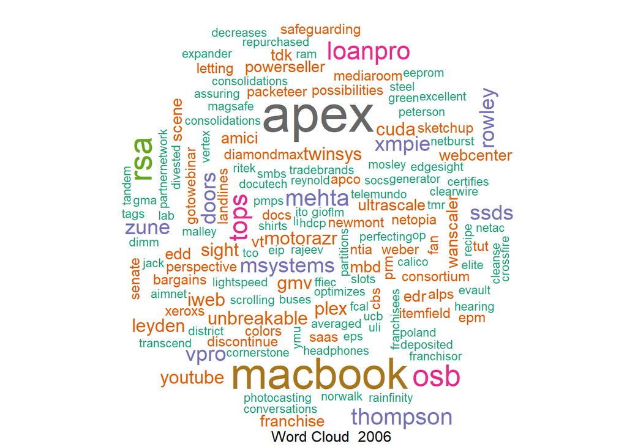

```r
  df2014afterdtm <- tidy(dtm)

saveRDS(dtm,paste0(RDSfilePath,year,'.Rds'))

df2014 = as.matrix((readRDS(paste0(RDSfilePath,year,'.Rds'))))

d2014 = df2014[,colSums(df2014)>0]


d30 = df2014[,colSums(df2014)>0]
add.words=(setdiff(colnames(d30),colnames(d2013)))

df2014afterdtm<-df2014afterdtm[df2014afterdtm$column %in% add.words,]

dfperyear=data.frame(freq=df2014afterdtm$value ,new.words=df2014afterdtm$column,year=year,stringsAsFactors = F)
df<- rbind(df, dfperyear)
# This Works----------------------



build_perYearCloud("2006",subset(df,year==2006))
```

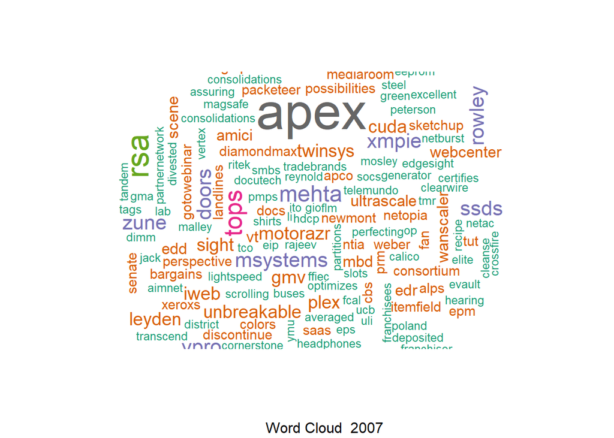

```r
build_perYearCloud("2007",subset(df,year==2007))
```

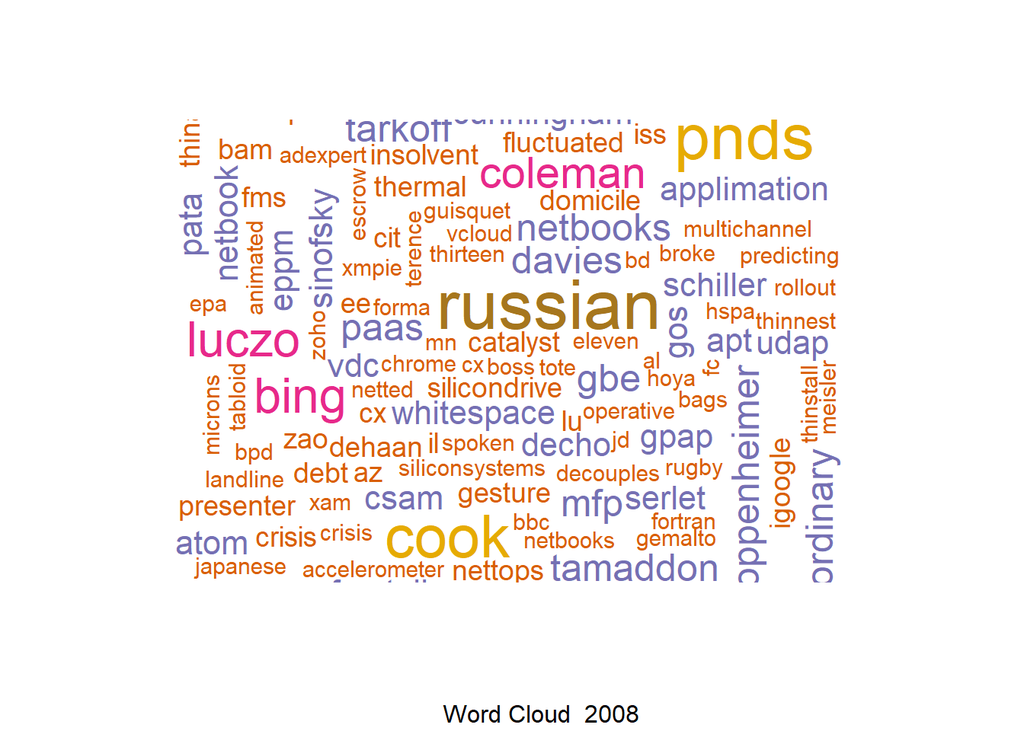

```r
build_perYearCloud("2008",subset(df,year==2008))
```

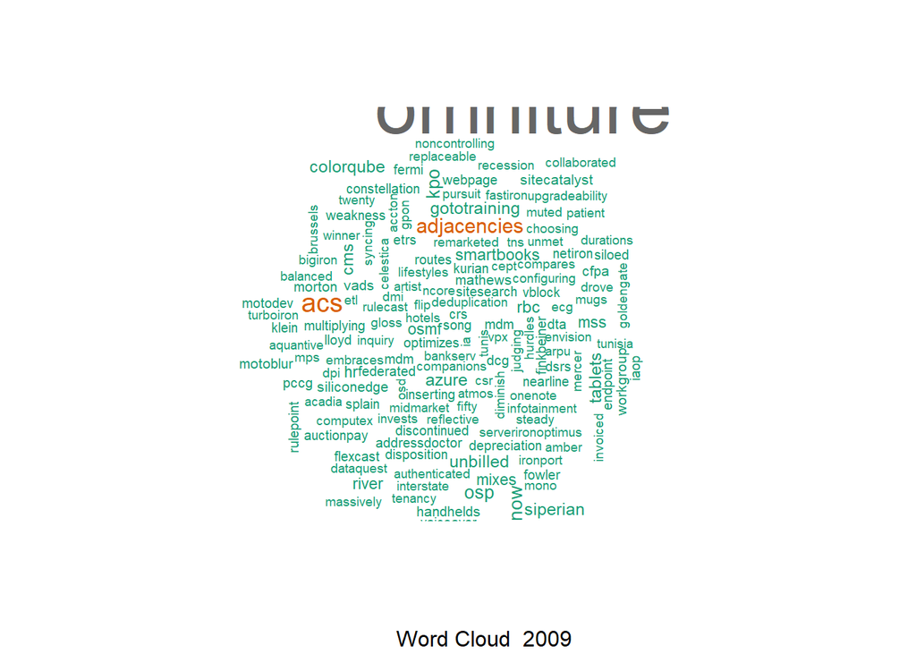

```r
build_perYearCloud("2009",subset(df,year==2009))
```

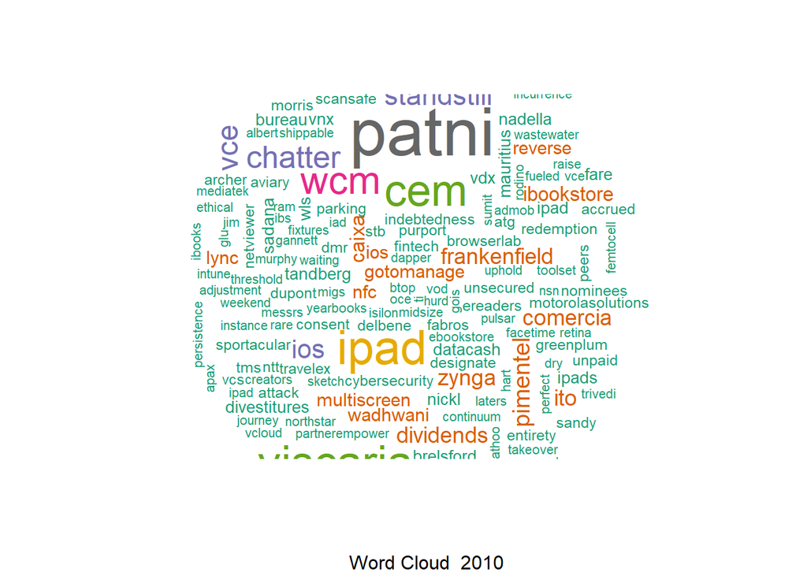

```r
build_perYearCloud("2010",subset(df,year==2010))
```